# Plots_in_R

Dane Dela Cruz

2023-06-08

# Visualizing Data in R

Below are visualizations that demonstrate my ability to create various plots to tell a data story.

## Libraries

```r
install.packages("tidyverse")
install.packages("ggridges")
install.packages("patchwork")
install.packages("viridis")
install.packages("viridisLite")
install.packages("gapminder")
install.packages("palmerpenguins")
library(tidyverse)
library(ggridges)
library(patchwork)
library(viridis)
library(viridisLite)
library(hrbrthemes)
library(gapminder)
library(palmerpenguins)
```

## Plots

### Box Plots

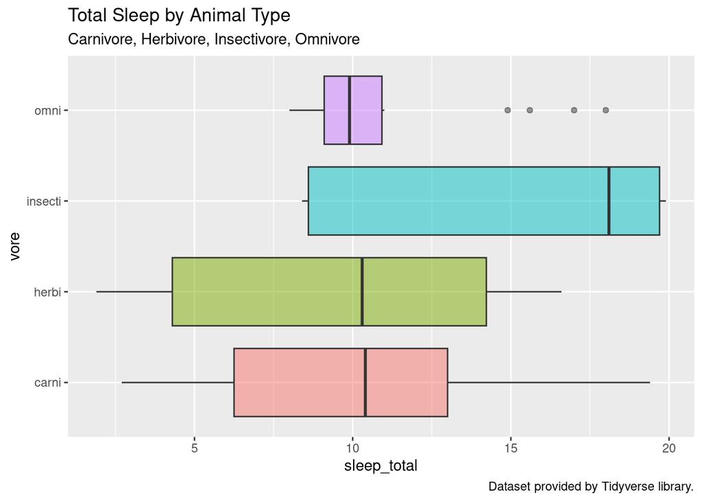

```r
msleep %>%
  drop_na(vore) %>%
  ggplot(aes(vore, sleep_total, fill = vore))+
  geom_boxplot(alpha = 0.5,
               show.legend = FALSE)+
  coord_flip()+
  labs(title = "Total Sleep by Animal Type",
       subtitle = "Carnivore, Herbivore, Insectivore, Omnivore",
       caption = "Dataset provided by Tidyverse library.")
```

Box plots are particularly useful when working with descriptive statistical analysis, i.e. finding the mean and median values within a dataset as well as the interquartile range. This plot gives you a quick summary of how much sleep animals get based on their diet group.

### Density Plots

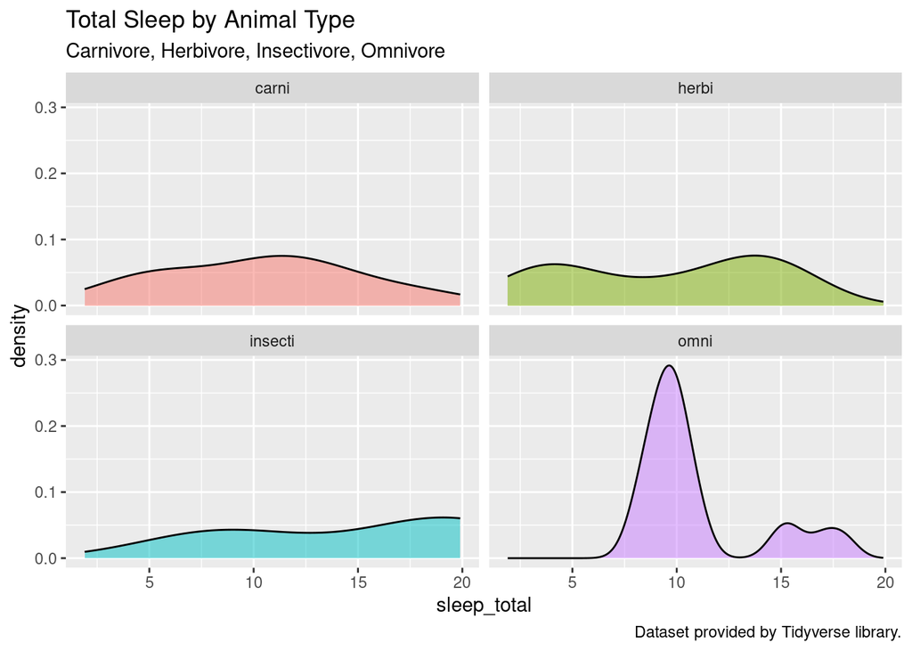

```r
msleep %>%
  drop_na(vore) %>%
  ggplot(aes(sleep_total, fill = vore))+
  geom_density(alpha = 0.5,
               show.legend = FALSE)+
  facet_wrap(~vore)+
  labs(title = "Total Sleep by Animal Type",
       subtitle = "Carnivore, Herbivore, Insectivore, Omnivore",
       caption = "Dataset provided by Tidyverse library.")
```

Density plots are used to visualize a distribution of data over a period of time or in a given range. With this plot, again using the msleep dataset, we can see the sleep distribution of each diet group.

##### Ridgeline Plots

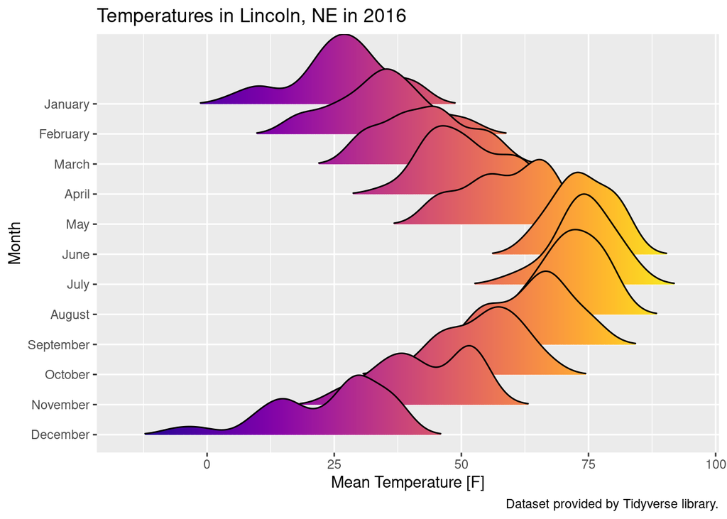

```r
lincoln_weather %>%
  ggplot(aes(x = `Mean Temperature [F]`, y = `Month`, fill = after_stat(x))) +
  geom_density_ridges_gradient(scale = 3,
                               rel_min_height = 0.01,
                               alpha = 5) +
  scale_fill_viridis(name = "Temp. [F]", option = "C") +
  labs(title = "Temperatures in Lincoln, NE in 2016",
       caption = "Dataset provided by Tidyverse library.") +
  theme(legend.position = "none",
        panel.spacing = unit(0.1, "lines"),
        strip.text.x = element_text(size=8))
```

A ridgeline plot is a collection of density plots that visualize multiple observations in a dataset like the one above.

### Scatter Plots

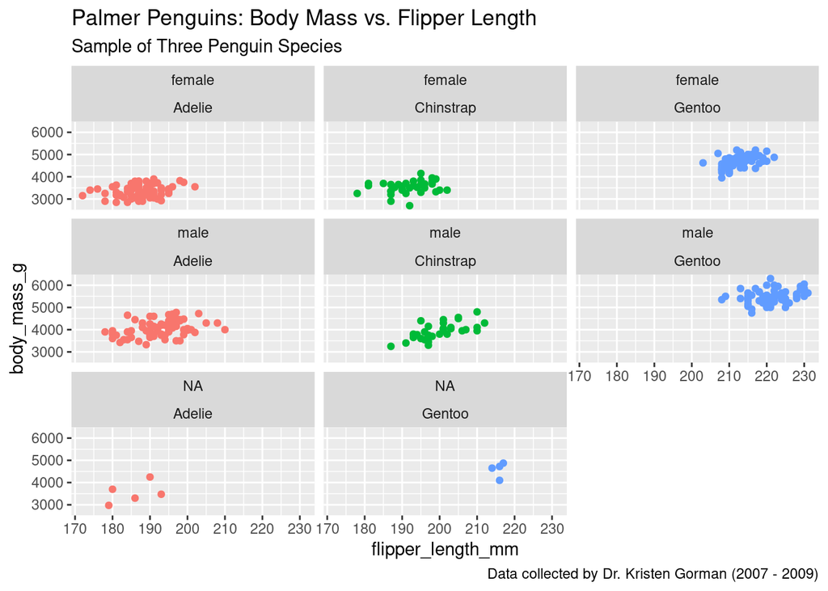

```r
penguins %>%
  ggplot(aes(x = flipper_length_mm, y = body_mass_g, color = species)) +
  geom_point(show.legend = FALSE) +
  facet_wrap(sex ~ species) +
  labs(title = "Palmer Penguins: Body Mass vs. Flipper Length",
       subtitle = "Sample of Three Penguin Species",
       caption = "Data collected by Dr. Kristen Gorman (2007 - 2009)")
```

Scatter plots are used to analyze correlations among dependent and independent variables. In this visualization, I have separated and grouped the gender and species variables to better understand the difference between each categorical variable’s observations.

### Lollipop Plots

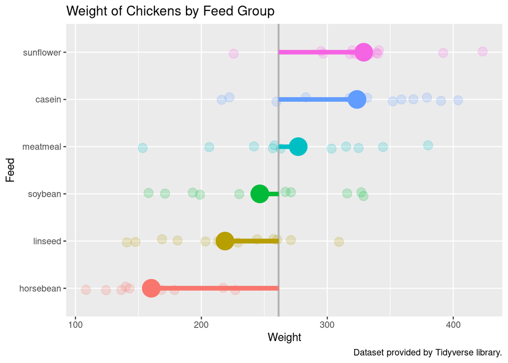

```r
chickwts %>%
  group_by(feed) %>%
  mutate(mean_by_feed = mean(weight)) %>%
  ungroup() %>%
  mutate(feed = fct_reorder(feed, mean_by_feed)) %>%
  ggplot(aes(feed, weight,
             colour = feed,
             show.legend = FALSE)) +
  coord_flip() + geom_jitter(show.legend = FALSE,
                             size = 4,
                             alpha = 0.2,
                             width = 0.05) +
  stat_summary(fun=mean, geom = "point",
               size = 8,
               show.legend = FALSE) +
  geom_hline(aes(yintercept = mean(weight)),
             colour = "gray70",
             linewidth = 0.9) +
  geom_segment(aes(x = feed, xend = feed, y = mean(weight),
                   yend = mean_by_feed),
               linewidth = 2,
               show.legend = FALSE) +
  labs(title = "Weight of Chickens by Feed Group",
       x="Feed",
       y="Weight",
       caption = "Dataset provided by Tidyverse library.") +
  theme(legend.position = "none")
```